# xwMOOC 모형

피처 공학 - 선택 혹은 추출

# 1 Feature 선택 혹은 추출 [^1]

Feature를 선택하는 것과 Feature를 추출하는 것은 다른 얘기가 된다. Feature를 선택하는 것을 `feature seleciton`, Feature를 추출하는 것은 `feature extraction`으로 피처 선택의 사례로 다양한 변수 선택기법을 들 수 있고, 피처 추출 사례로 주성분 분석(PCA)를 예로 들면 이해가 쉬을 듯 싶다.

## 1.1 데이터셋 - 미군 신체측정

[미군 신체측정 데이터셋(Anthropometric Survey of US Army Personnel, ANSUR 2)](http://www.openlab.psu.edu/ansur2/)은 2012년 내부에 공개되었고 2017년에 대중에 공개되었다. 총 6,000명 군인(남자 4,082, 여자 1,986)에 대한 측정정보를 담고 있다.

```r
library(tidyverse)
male_dat <- read_csv("http://tools.openlab.psu.edu/publicData/ANSUR_II_MALE_Public.csv")
female_dat <- read_csv("http://tools.openlab.psu.edu/publicData/ANSUR_II_FEMALE_Public.csv")

soldier_dat <- bind_rows(male_dat, female_dat)

soldier_dat %>% write_rds("data/soldier_dat.rds")
```

다운로드 받은 남녀 데이터를 결합하여 남자군인, 여자군인을 분류하는데 사용되는 `X` 설계행렬을 추출한다.

```r
soldier_dat <- read_rds("data/soldier_dat.rds")

soldier_X_df <- soldier_dat %>%
  select(-c("subjectid","SubjectId", "Gender", "Date", "Installation",  "Component", "Branch", "PrimaryMOS", "SubjectsBirthLocation",  "SubjectNumericRace", "Ethnicity", "DODRace", "Age", "Heightin", "Weightlbs", "WritingPreference"))

soldier_X_df
```

```
# A tibble: 6,068 x 93
   abdominalextens… acromialheight acromionradiale… anklecircumfere…
              <dbl>          <dbl>            <dbl>            <dbl>
 1              266           1467              337              222
 2              233           1395              326              220
 3              287           1430              341              230
 4              234           1347              310              230
 5              250           1585              372              247
 6              263           1407              344              216
 7              314           1476              343              257
 8              304           1529              360              254
 9              321           1457              339              230
10              227           1481              345              233
# … with 6,058 more rows, and 89 more variables: axillaheight <dbl>,
#   balloffootcircumference <dbl>, balloffootlength <dbl>,
#   biacromialbreadth <dbl>, bicepscircumferenceflexed <dbl>,
#   bicristalbreadth <dbl>, bideltoidbreadth <dbl>,
#   bimalleolarbreadth <dbl>, bitragionchinarc <dbl>,
#   bitragionsubmandibulararc <dbl>, bizygomaticbreadth <dbl>,
#   buttockcircumference <dbl>, buttockdepth <dbl>, buttockheight <dbl>,
#   buttockkneelength <dbl>, buttockpopliteallength <dbl>,
#   calfcircumference <dbl>, cervicaleheight <dbl>, chestbreadth <dbl>,
#   chestcircumference <dbl>, chestdepth <dbl>, chestheight <dbl>,
#   crotchheight <dbl>, crotchlengthomphalion <dbl>,
#   crotchlengthposterioromphalion <dbl>, earbreadth <dbl>,
#   earlength <dbl>, earprotrusion <dbl>, elbowrestheight <dbl>,
#   eyeheightsitting <dbl>, footbreadthhorizontal <dbl>, footlength <dbl>,
#   forearmcenterofgriplength <dbl>, forearmcircumferenceflexed <dbl>,
#   forearmforearmbreadth <dbl>, forearmhandlength <dbl>,
#   functionalleglength <dbl>, handbreadth <dbl>, handcircumference <dbl>,
#   handlength <dbl>, headbreadth <dbl>, headcircumference <dbl>,
#   headlength <dbl>, heelanklecircumference <dbl>, heelbreadth <dbl>,
#   hipbreadth <dbl>, hipbreadthsitting <dbl>, iliocristaleheight <dbl>,
#   interpupillarybreadth <dbl>, interscyei <dbl>, interscyeii <dbl>,
#   kneeheightmidpatella <dbl>, kneeheightsitting <dbl>,
#   lateralfemoralepicondyleheight <dbl>, lateralmalleolusheight <dbl>,
#   lowerthighcircumference <dbl>, mentonsellionlength <dbl>,
#   neckcircumference <dbl>, neckcircumferencebase <dbl>,
#   overheadfingertipreachsitting <dbl>, palmlength <dbl>,
#   poplitealheight <dbl>, radialestylionlength <dbl>,
#   shouldercircumference <dbl>, shoulderelbowlength <dbl>,
#   shoulderlength <dbl>, sittingheight <dbl>,
#   sleevelengthspinewrist <dbl>, sleeveoutseam <dbl>, span <dbl>,
#   stature <dbl>, suprasternaleheight <dbl>, tenthribheight <dbl>,
#   thighcircumference <dbl>, thighclearance <dbl>, thumbtipreach <dbl>,
#   tibialheight <dbl>, tragiontopofhead <dbl>, trochanterionheight <dbl>,
#   verticaltrunkcircumferenceusa <dbl>, waistbacklength <dbl>,
#   waistbreadth <dbl>, waistcircumference <dbl>, waistdepth <dbl>,
#   waistfrontlengthsitting <dbl>, waistheightomphalion <dbl>,
#   weightkg <dbl>, wristcircumference <dbl>, wristheight <dbl>
```

# 2 변수 선택

## 2.1 결측점

Feature 선택에 있어 가장 먼저 결측점이 있는지 파악하고 각 feature별로 결측점 비율을 파악해서 특정 결측비율이상되면 제외시키도록한다.

가장 먼저 데이터프레임 변수별로 결측값이 있는 다음 무명함수로 확인한다.

```r
soldier_X_df %>%
   select_if(function(x) any(is.na(x)))
```

```
# A tibble: 6,068 x 0
```

결측값 갯수를 각 변수별로 산출하고 이를 데이터프레임으로 변환시킨다. 다행히 결측값은 하나도 없는 것으로 판정되어 제거할 feature도 없다.

```r
soldier_na_vec <- sapply(soldier_X_df, function(y) sum(length(which(is.na(y)))))
soldier_na_df  <- tibble(na_cnt = soldier_na_vec)

soldier_na_df %>%
  mutate(na_pcnt = na_cnt / nrow(soldier_na_df) * 100) %>%
  arrange(desc(na_pcnt))
```

```
# A tibble: 93 x 2
   na_cnt na_pcnt
    <int>   <dbl>
 1      0       0
 2      0       0
 3      0       0
 4      0       0
 5      0       0
 6      0       0
 7      0       0
 8      0       0
 9      0       0
10      0       0
# … with 83 more rows
```

## 2.2 산포 거의 0

산포가 거의 0인 변수는 의미가 없다. 따라서 각 변수 분산을 구한 후에 분산이 0 혹은 분산이 거의 0인 변수를 제거한다. 이번 경우에도 산포가 0인 변수가 없어 제거할 변수가 없다.

```r
soldier_X_df %>%
  gather(variable, value) %>%
  group_by(variable) %>%
  summarise(variance = sd(value),
            na_cnt = sum(length(which(is.na(value))))) %>%
  arrange(variance)
```

```
# A tibble: 93 x 3
   variable              variance na_cnt
   <chr>                    <dbl>  <int>
 1 earprotrusion             3.17      0
 2 earbreadth                3.23      0
 3 earlength                 4.88      0
 4 bimalleolarbreadth        5.34      0
 5 heelbreadth               5.93      0
 6 headbreadth               6.24      0
 7 handbreadth               6.35      0
 8 footbreadthhorizontal     6.66      0
 9 tragiontopofhead          6.66      0
10 palmlength                7.14      0
# … with 83 more rows
```

## 2.3 상관계수

`soldier_X_df` 데이터프레임은 93 변수로 구성되어 있어 수작업으로 일일이 상관관계를 파악하는 것은 불가능하다고 보고 `corrr` 팩키지를 사용해서 상관관계를 계산하고 상관관계가 높은 변수를 뽑아낸다.

```r
library(corrr)
soldier_X_df %>%
  correlate() %>%
  shave() %>%
  stretch() %>%
  arrange(desc(r))
```

```
# A tibble: 8,649 x 3
   x                y                       r
   <chr>            <chr>               <dbl>
 1 cervicaleheight  stature             0.991
 2 cervicaleheight  suprasternaleheight 0.989
 3 stature          suprasternaleheight 0.989
 4 acromialheight   axillaheight        0.987
 5 acromialheight   suprasternaleheight 0.985
 6 acromialheight   cervicaleheight     0.984
 7 eyeheightsitting sittingheight       0.982
 8 axillaheight     suprasternaleheight 0.981
 9 acromialheight   stature             0.980
10 axillaheight     cervicaleheight     0.977
# … with 8,639 more rows
```

# 3 Feature 추출

Feature 추출은 PCA의 사례를 통해 이해하면 쉬울 듯 싶다. 즉 기존 변수를 조합해서 신규 변수를 추출하는 것을 생각하면 될 듯 싶다.

## 3.1 축소 차원

`prcomp` 함수로 PCA를 수행하고 팔꿈치 그래프를 통해서 적절한 차원수를 결정한다.

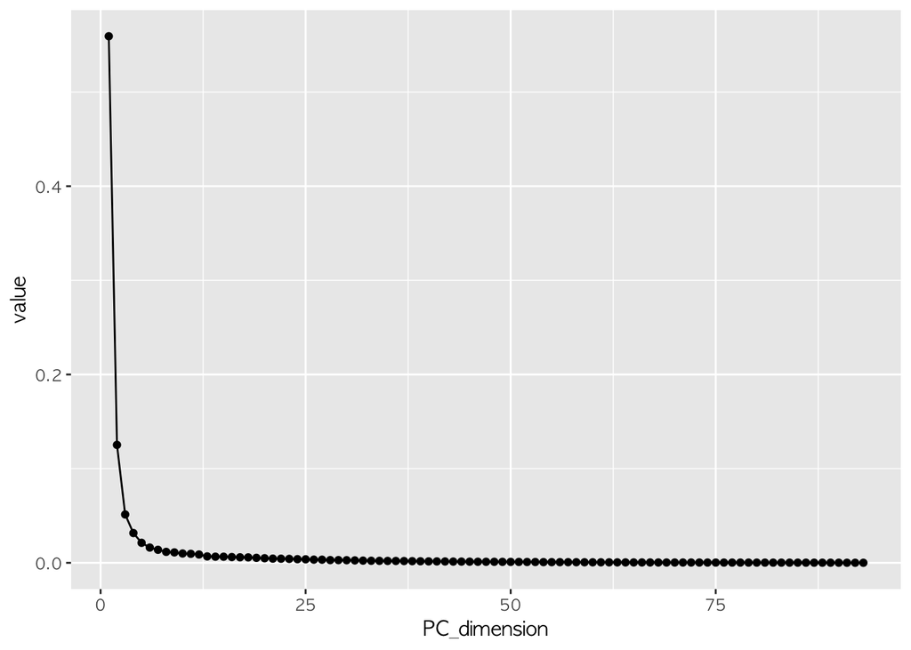

```r
soldier_pca <- soldier_X_df %>%
  prcomp(scale = TRUE, center = TRUE)

soldier_pca_summary <- summary(soldier_pca)

soldier_pca_df <- soldier_pca_summary$importance %>%
  tbl_df() %>%
  mutate(names = rownames(soldier_pca_summary$importance)) %>%
  gather(PC, value, -names) %>%
  arrange(names, PC)

soldier_pca_df %>%
  filter(str_detect(names, "Variance")) %>%
  mutate(PC_dimension = parse_number(PC)) %>%
  ggplot(aes(x=PC_dimension, y=value)) +
    geom_point() +
    geom_line()
```

## 3.2 Feature 추출

다음 단계로 정해진 차원에 맞춰 Feature를 추출한다. 그리고 목적으로 하고 있는 예측할 변수(`Gender`)를 붙여 basetable을 구성한다.

```r
soldier_pca_X_df <- soldier_pca$x[,1:3] %>%
  tbl_df

soldier_df <- soldier_dat %>%
  select(Gender) %>%
  bind_cols(soldier_pca_X_df)

soldier_df %>%
  sample_n(100) %>%
  DT::datatable()
```

|  | Gender | PC1 | PC2 | PC3 |
| --- | --- | --- | --- | --- |
| 1 | Female | 1.70950894295506 | 3.66983071605568 | 3.75506703125185 |
| 2 | Male | -11.0140899357769 | -4.32476516150489 | 1.5115736847497 |
| 3 | Male | -11.020044245125 | 2.34085060038152 | -1.32426754501008 |
| 4 | Male | -0.35772572621894 | -0.37107776328435 | -4.38241305902313 |
| 5 | Female | 5.31231960964362 | 4.63444412292375 | 0.62261332822409 |
| 6 | Male | -3.15897922528624 | -0.776707998637449 | -1.85476093184797 |
| 7 | Male | -2.70259739634548 | 1.78106062275881 | -0.133013462041191 |
| 8 | Male | -1.64779870311305 | 3.88553550472548 | -2.53009704696389 |
| 9 | Male | -4.71512079419722 | -3.65424410098617 | 0.424640211149708 |
| 10 | Female | -1.36173580109769 | 5.64699692930836 | 2.68263791347691 |

[output cut: 90 more lines]

## 3.3 추출된 Feature 시각화

추출된 Feature에 대한 시각화를 수행한다. PC1, PC2 추출된 Feature로 남자군인과 여성군인 특성차를 나름대로 확인할 수 있다.

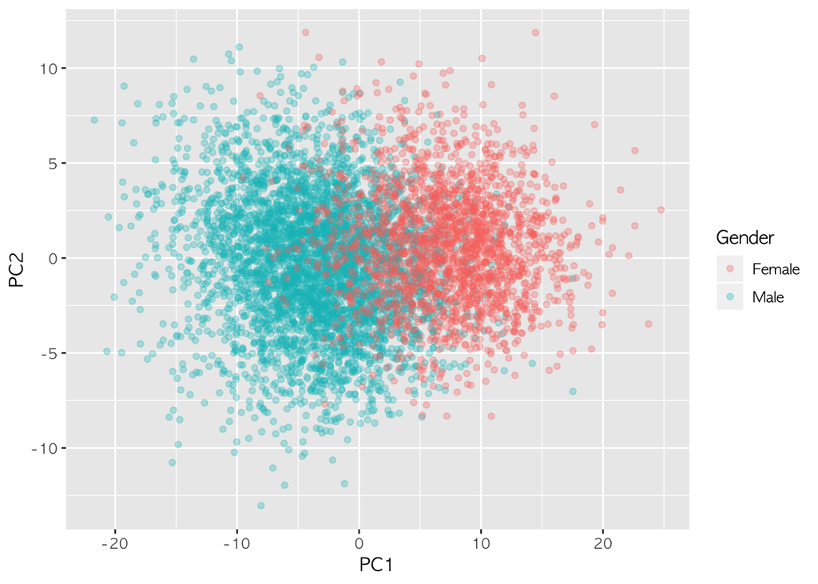

```r
soldier_df %>%
  ggplot(aes(x=PC1, y=PC2, color=Gender)) +
    geom_point(alpha=0.3)
```

## 3.4 추출된 Feature 설명

추출된 Feature에 대해서 원본데이터에서 요인을 추가로 붙여 추가 설명도 가능하다. BMI 변수를 새로 도입하여 추가하는 것도 흥미로울 듯 싶은데, 기존에 있던 연령 정보를 활용하여 신규로 5개 연령집단으로 나눠 남녀군인을 겹쳐 추출된 Feature를 설명하는 것도 좋을 듯 싶다.

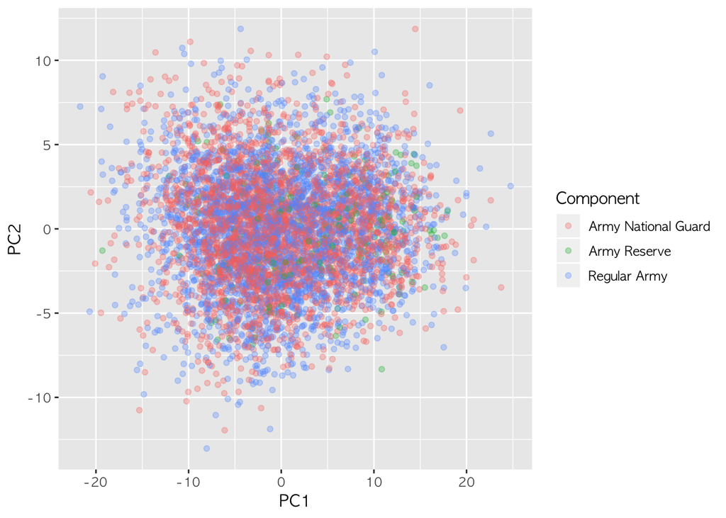

```r
soldier_dat %>%
  select(Component) %>%
  bind_cols(soldier_pca_X_df) %>%
    ggplot(aes(x=PC1, y=PC2, color=Component)) +
    geom_point(alpha=0.3)
```

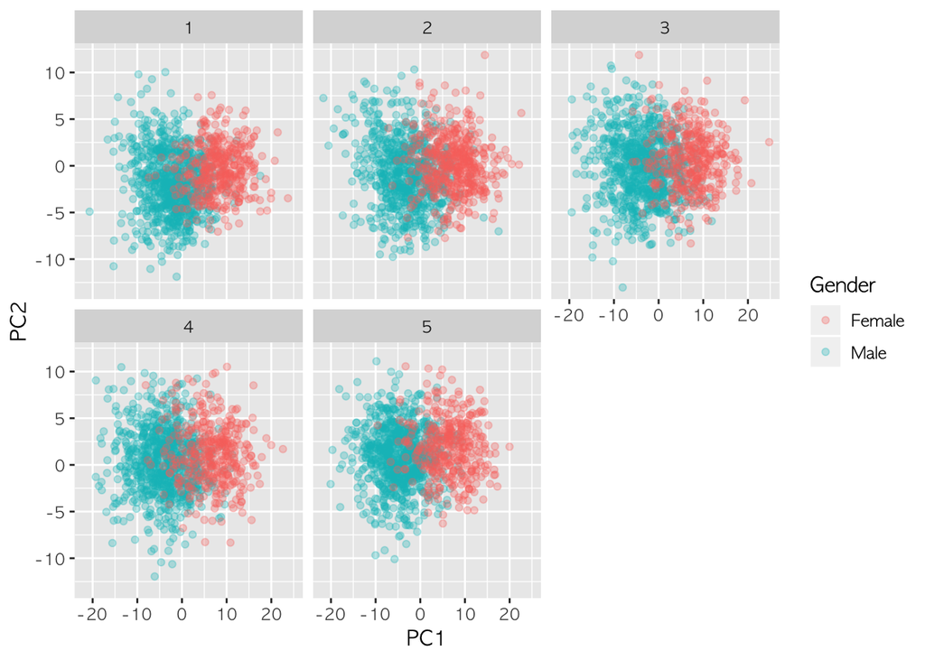

```r
soldier_dat %>%
  mutate(Age_group = ntile(Age, 5) %>% as.factor) %>%
  select(Gender, Age_group) %>%
    bind_cols(soldier_pca_X_df) %>%
    ggplot(aes(x=PC1, y=PC2, color=Gender)) +
    geom_point(alpha=0.3) +
    facet_wrap(~Age_group)
```

[^1]: [Max Kuhn and Kjell Johnson, (2019-02-22), “Feature Engineering and Selection: A Practical Approach for Predictive Models”](http://www.feat.engineering/index.html)